# Good practices for sharing research code

Scientific workflows: Tools and Tips 🛠️

2026-07-16

## What is this lecture series?

### Scientific workflows: Tools and Tips 🛠️

📅 Every 3rd Thursday 🕓 4-5 p.m. 📍 Webex

- One topic from the world of scientific workflows
- Material provided [online](https://selinazitrone.github.io/tools_and_tips/)
- If you don’t want to miss a lecture
  - [Subscribe to the mailing list](https://lists.fu-berlin.de/listinfo/toolsAndTips)

## Code sharing in Ecology

[figure not shown]

1861 ecology papers from 7 journals (2017-2024)

## Sharing code is still the exception (?)

- Data is often shared, code not
- Shared code is often not sufficient
  - low reproducibility
  - missing a README (39%)
  - low-quality READMEs
  - missing license (26%) or wrong license
  - …

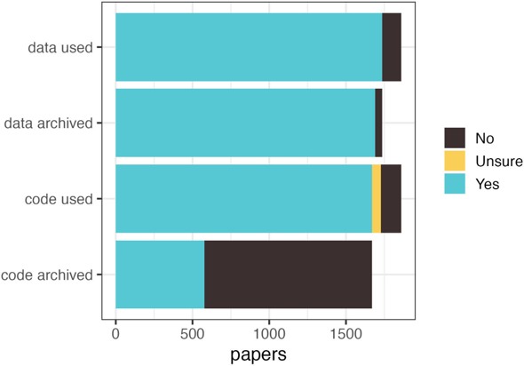

[Cooper et al. (2026)](https://doi.org/10.1111/2041-210X.70338), *Methods in Ecology and Evolution*

[Cooper et al. (2026)](https://doi.org/10.1111/2041-210X.70338), *Methods in Ecology and Evolution*; [Culina et al. (2020)](https://doi.org/10.1371/journal.pbio.3000763), *Plos Biology*

## Why?

- Time pressure - not a priority
- Journals still often don’t require it
- Code is not part of peer review
- Not sure how to do it properly

## Code sharing is worth it

- Open science creates trust
- Reproducibility: Results can be verified
- Reusability: Others (including future you) can build on your work
- Visibility: Credit, collaborations
- A portfolio of your coding skills

## Today

- How to build and publish a good practice repository
- Checklist with the most important things to do
- Focus on data analysis projects
- Where AI tools can help

## What we will not talk about

- Research software (packages, libraries, tools)
- Writing code (Good coding practices, style, functions, testing, etc …)
  - For this check out the lecture [R code that lasts](https://selinazitrone.github.io/tools_and_tips/sessions/10_r-code-that-lasts.html) and some other resources linked on the website
- Too many language specific details (but some R and Python hints)

## Our example project

My paper is accepted: *“Temperature and antibiotic resistance in soil bacteria”*.

Now I need to publish code and data

```
temperature-resistance/
├── clean.R
├── analysis_final.R
├── makeplots.R
├── growth_assay.csv
├── growth_assay_clean.csv
├── results.csv
└── Rplot01.png
```

Let’s make this repo publishable!

# Structure & orientation

> Can someone understand it?

## Separate your files into folders

- Most important: separate data, code, and output
- Separate raw data (read-only) from processed data (produced by scripts)
- Follow a template or use your own structure, as long as it is clear and consistent (keyword: research compendium)

```
temperature-resistance/
├── data/
│   ├── raw/
│   │   └── growth_assay.csv
│   └── clean/
│       └── growth_assay_clean.csv
├── analysis/
│   ├── clean.R
│   ├── analysis_final.R
│   └── makeplots.R
└── output/
    ├── figures/
    │   └── Rplot01.png
    └── tables/
        └── results.csv
```

Our messy project, sorted into folders

Further reading: rrtools (R), [research compendia with computational notebooks](https://github.com/FellowsFreiesWissen/computational_notebooks) (R), [Cookiecutter Data Science](https://cookiecutter-data-science.drivendata.org/) (Python)

## Use informative file names

- Human readable: reveal the content
- Machine readable: no spaces, no special characters
- Work with default ordering: left-padded numbers or YYYY-MM-DD dates first

```
temperature-resistance/
├── data/
│   ├── raw/
│   │   └── growth_assay.csv
│   └── clean/
│       └── cleaned_data.csv
├── analysis/
│   ├── 01_clean-data.R
│   ├── 02_fit-models.R
│   └── 03_make-figures.R
└── output/
    ├── figures/
    │   └── linear-model-fit.png
    └── tables/
        └── model-results.csv
```

Our project with nicer file names

More on naming: [Jenny Bryan’s talk](https://speakerdeck.com/jennybc/how-to-name-files) on how to name files

## Add a thorough README

- README’s are the entry point to your project
- A README should be a simple text format (plain text or Markdown)

```
temperature-resistance/
├── README.md
├── data/
│   ├── raw/
│   │   └── growth_assay.csv
│   └── clean/
│       └── cleaned_data.csv
├── analysis/
│   ├── 01_clean-data.R
│   ├── 02_fit-models.R
│   └── 03_make-figures.R
└── output/
    ├── figures/
    │   └── linear-model-fit.png
    └── tables/
        └── model-results.csv
```

## What a README should do

At minimum, a README should answer:

- **What** the project is, and which **paper** it belongs to
- **How to run it** (how to install, which order to run the scripts)
- **How the files are structured** (what is in each folder, what the files are)
- **How to cite** the project
- **Who to ask** when it breaks

## A README skeleton

```markdown
# Temperature and antibiotic resistance in soil bacteria

Code and data for: Baldauf et al. (2026), *Journal*, doi:10.xxxx/xxxxx

Cite as: Baldauf et al. (2026). Data and code for "Temperature and antibiotic resistance in soil bacteria". doi:10.xxxx/xxxxx

Code is licensed under MIT, data under CC-BY-4.0. See `LICENSE` and `data/LICENSE` for details.

## How to run

Download or clone the repository to run it locally.

The project needs R version 4.0.0 or higher.

1. Restore the environment: `renv::restore()` - This will create a project library and install all required packages.
2. Run `main.R`, which runs all analysis scripts in order

## Project structure

- `analysis/`      analysis scripts, run in numerical order
- `data/raw/` the original growth-assay measurements (read-only)
- `data/clean/` cleaned data produced by the scripts
- `output/` figures and tables produced by the scripts

### `analysis/`

- `01_clean-data.R`: cleans the raw data and saves it
    - Input: `data/raw/growth_assay.csv`
    - Output: `data/clean/cleaned_data.csv`
- `02_fit-models.R`: fits the models and saves the results table
    - Input: `data/clean/cleaned_data.csv`
    - Output: `output/tables/model-results.csv`
- `03_make-figures.R`: makes the manuscript figures
    - Input: `data/clean/cleaned_data.csv`, `output/tables/model-results.csv`
    - Output: `output/figures/linear-model-fit.png` (Figure 2)

### `data/`

See `data/README.md` for a description of all data variables.

## Contact
selina.baldauf@fu-berlin.de
```

## Some examples of good README files

- https://github.com/lciernik/attentive-layer-fusion
- https://github.com/openplantpathology/Reproducibility_in_Plant_Pathology
- https://github.com/paocorrales/t-drop-trends

# Running the code

> Can someone rerun it?

## Make the run order obvious

**Level 1**: Number your scripts `01_`, `02_`, etc. and add this to the “How to run” section in the README.

```markdown
## How to run

1. Install dependencies with `renv::restore()`
2. Run the scripts in numerical order:
    1. `01_clean-data.R`
    2. `02_fit-models.R`
    3. `03_make-figures.R`
```

```
temperature-resistance/
├── README.md
├── data/
│   ├── raw/
│   │   └── growth_assay.csv
│   └── clean/
│       └── cleaned_data.csv
├── analysis/
│   ├── 01_clean-data.R
│   ├── 02_fit-models.R
│   └── 03_make-figures.R
└── output/
    ├── figures/
    │   └── linear-model-fit.png
    └── tables/
        └── model-results.csv
```

## Make the run order obvious

**Level 2**: Create a **main script** that calls all scripts in order, so this is the only file someone needs to open.

- main.R
- main.py

```r
# Run the whole analysis pipeline

# Step 1: Clean the data
# Input: `data/raw/growth_assay.csv`
# Output: `data/clean/cleaned_data.csv`
source("analysis/01_clean-data.R")
# Step 2: Fit the models and produce table 1
# Input: `data/clean/cleaned_data.csv`
# Output: `output/tables/model-results.csv`
source("analysis/02_fit-models.R")
# Step 3: Make all manuscript figures
# Input: `data/clean/cleaned_data.csv`, `output/tables/model-results.csv`
# Output: `output/figures/linear-model-fit.png` (Figure 2)
source("analysis/03_make-figures.R")
```

```python
# Run the whole analysis pipeline
from clean_data import main as clean_data
from fit_models import main as fit_models
from make_figures import main as make_figures

if __name__ == "__main__":
    # Step 1: Clean the data
    # Input: `data/raw/growth_assay.csv`
    # Output: `data/clean/cleaned_data.csv`
    clean_data()
    # Step 2: Fit the models and produce table 1
    # Input: `data/clean/cleaned_data.csv`
    # Output: `output/tables/model-results.csv`
    fit_models()
    # Step 3: Make all manuscript figures
    # Input: `data/clean/cleaned_data.csv`, `output/tables/model-results.csv`
    # Output: `output/figures/linear-model-fit.png` (Figure 2)
    make_figures()
```

```
temperature-resistance/
├── README.md
├── main.R
├── data/
│   ├── raw/
│   │   └── growth_assay.csv
│   └── clean/
│       └── cleaned_data.csv
├── analysis/
│   ├── 01_clean-data.R
│   ├── 02_fit-models.R
│   └── 03_make-figures.R
└── output/
    ├── figures/
    │   └── linear-model-fit.png
    └── tables/
        └── model-results.csv
```

## Make the run order obvious

**Level 3**: Use **workflow management tools** like [targets](https://books.ropensci.org/targets/) (R) or [Snakemake](https://snakemake.readthedocs.io/en/stable/) (any language). Define workflows, automatically run the steps in the right order and only rerun what changed.

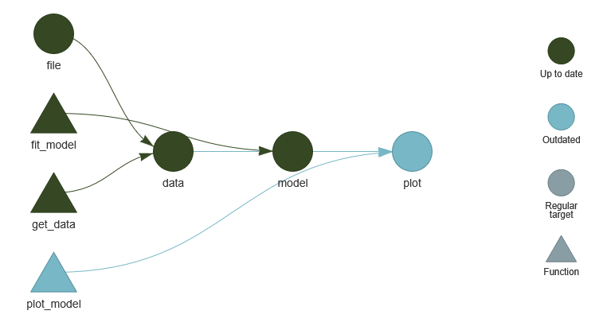

An example workflow from the [targets package](https://books.ropensci.org/targets/walkthrough.html)

## Record all dependencies and versions

Let people know what they need to install to make the code work.

- The language itself and its version (e.g. R 4.4.1, Python 3.12)
- All libraries/packages and their versions
- Any other programs your code calls

## Record all dependencies and versions

**Level 1**: Copy-paste dependencies into the README. Easy, but less convenient for people who need to install the software.

- R
- Python
- Run `sessionInfo()` at the **end** of your pipeline (so every package is loaded), then paste the package list into the README.
- `renv::dependencies()` also lists the packages your code uses, but without versions.

[session information not shown]

```
#> R version 4.4.1 (2024-06-14)
#> ...
#> other attached packages:
#> [1] ggplot2_3.5.1 dplyr_1.1.4   readr_2.1.5
```

- Run `pip freeze` **inside** your project’s **virtual environment**, then paste the list into the README.
- `pipreqs` (install with `pip install pipreqs`) scans your code for the packages you actually import, like `renv::dependencies()`.

```bash
$ pip freeze
pandas==2.2.2
numpy==1.26.4
matplotlib==3.9.0
```

## Record all dependencies and versions

**Level 2**: Snapshot your local environment so users can recreate them easily.

- R
- Python

Use the [`renv` package](https://rstudio.github.io/renv/) to:

- `renv::init()`: set up a project library and record all packages in a `renv.lock` file
- `renv::snapshot()`: update your lockfile with new packages
- `renv::restore()`: recreate the environment on another machine

Use [`uv`](https://docs.astral.sh/uv/) to:

- `uv init`: set up a project that records dependencies in a `pyproject.toml`
- `uv add pandas`: install a package and pin all exact versions in a `uv.lock` file
- `uv sync`: recreate the environment on another machine (including the right Python version)

## Record all dependencies and versions

**Level 3**: Package the whole environment in a **container** (e.g. [Docker](https://www.docker.com/)) so the code runs identically on any machine. Powerful but also more to learn and maintain.

- R
- Python
- The [Rocker project](https://rocker-project.org/) gives you different R images to build on.
- Start from an official [`python` base image](https://hub.docker.com/_/python) (e.g. `python:3.12-slim`) and install your dependencies in it
- [`uv`](https://docs.astral.sh/uv/guides/integration/docker/) also provides Docker images
- **No Dockerfile needed:** [repo2docker](https://repo2docker.readthedocs.io/) builds the image from a `requirements.txt` or `environment.yml`

## Use paths relative to project root

- Paths anchored to the project root work on any machine, from any working directory
- Absolute paths (`C:/Users/selina/PhD/...`) will break the project
- R
- Python

Use an R project (`.Rproj`, in RStudio or Positron) and the [`here` package](https://here.r-lib.org/). `here()` finds the root by searching upward for a marker (`.Rproj`, `.git`, `.here`), independent of the working directory:

```r
library(here)
read.csv(here("data", "raw", "growth_assay.csv"))
```

Use the [`pyprojroot` package](https://pypi.org/project/pyprojroot/), the equivalent of R’s `here`. It also has a `here()` function that finds the root, so paths resolve correctly from everywhere:

```python
from pyprojroot.here import here
import pandas as pd
pd.read_csv(here("data/raw/growth_assay.csv"))
```

# Data

> Can someone understand the data situation?

## Save your data in open formats

- Save data in **open formats**: `.csv`, `.tsv`, `.txt`, `.json`, `.parquet`, etc.
- Avoid proprietary formats: `.xlsx`, `.sav`, `.dta`, etc.

```
temperature-resistance/
├── README.md
├── main.R
├── renv.lock
├── data/
│   ├── raw/
│   │   └── growth_assay.csv
│   └── clean/
│       └── cleaned_data.csv
├── analysis/
│   ├── 01_clean-data.R
│   ├── 02_fit-models.R
│   └── 03_make-figures.R
└── output/
    ├── figures/
    │   └── linear-model-fit.png
    └── tables/
        └── model-results.csv
```

## Document your data files

Describe all your data files: Variable names, units, missing data codes, and other relevant information.

E.g. one table per file:

| Variable | Meaning | Unit / coding |
| --- | --- | --- |
| `sample_id` | Unique sample identifier | text |
| `temp` | Incubation temperature | °C |
| `resistant` | Grew on antibiotic plate | 0 = no, 1 = yes |
| `mic` | Minimum inhibitory concentration | mg/L |

## Document your data files

- Add documentation to the main README
- Or create a separate `data/README.md` for all data files

Main README:

```markdown
### `data/`

The `data/` folder contains the raw and cleaned
growth assay measurements.
See `data/README.md` for all variables.
```

```
temperature-resistance/
├── README.md
├── main.R
├── renv.lock
├── data/
│   ├── README.md
│   ├── raw/
│   │   └── growth_assay.csv
│   └── clean/
│       └── cleaned_data.csv
├── analysis/
│   ├── 01_clean-data.R
│   ├── 02_fit-models.R
│   └── 03_make-figures.R
└── output/
    ├── figures/
    │   └── linear-model-fit.png
    └── tables/
        └── model-results.csv
```

# Licence & citation

> Can someone legally reuse and cite it?

## Add a licence

- Without a licence file, people can not reuse your code
- Most popular licences in ecology are:
  - Creative commons licences (CC0, CC-BY)
  - MIT & GNU General Public License (GPL)
- Careful: CC licenses are NOT for code, only data & text

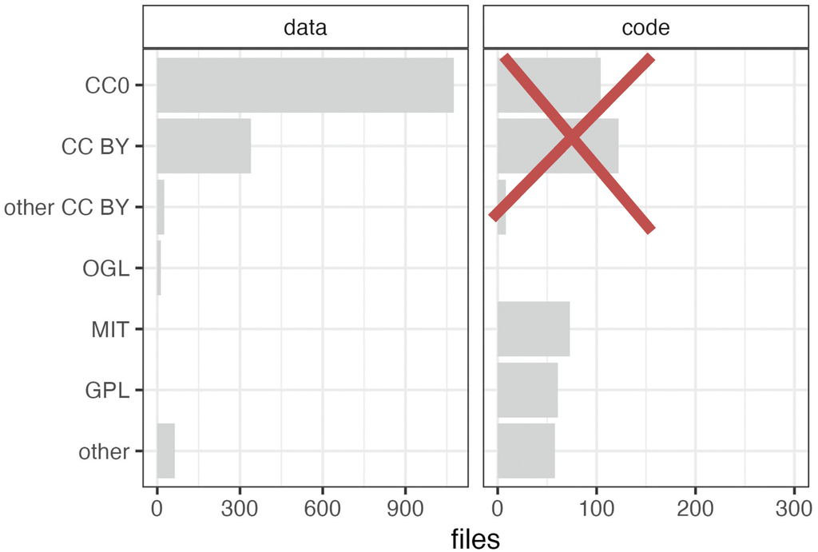

Number of licences used for code and data in BES ecology papers. [Cooper et al. (2026)](https://doi.org/10.1111/2041-210X.70338), *Methods in Ecology and Evolution*

## Which licence to choose?

- Are there specific requirements for your project?
- Checkout choosealicense.com to guide through licence choice

Standard open licences:

| Licence | What it does | For |
| --- | --- | --- |
| [CC0](https://choosealicense.com/licenses/cc0-1.0/) | Public-domain waiver, no attribution required | Data |
| [CC BY](https://choosealicense.com/licenses/cc-by-4.0/) | Reuse for any purpose, attribution required | Data |
| [MIT](https://choosealicense.com/licenses/mit/) | Permissive: reuse freely, keep the notice | Code |
| [GNU GPL v3](https://choosealicense.com/licenses/gpl-3.0/) | Copyleft: derivatives stay open, same licence | Code |

Further reading: The [Turing way book](https://book.the-turing-way.org/reproducible-research/licensing/) on licensing; [A case for CC0](https://blog.datadryad.org/2023/05/30/good-data-practices-removing-barriers-to-data-reuse-with-cc0-licensing/) by theDRYAD repository

## How to add a licence

Many different ways. In general: Add a `LICENSE` file containing the licence text into the repository.

- Manual
- GitHub
1. Create a `LICENSE` file
2. Go to choosealicense.com and copy the text of your chosen licence into the file
3. Add your name and the year to the licence text (if needed, e.g. for MIT license)

Add file → Create new file → name it `LICENSE` → **“Choose a license template”**

```
temperature-resistance/
├── README.md
├── LICENSE
├── main.R
├── renv.lock
├── data/
│   ├── README.md
│   ├── LICENSE
│   ├── raw/
│   └── clean/
├── analysis/
└── output/
```

Make it clear in the README what is the licence for code and data, e.g.:

```
All files in `/data` are licensed under CC-BY-4.0, all other files are licensed under MIT. See `data/LICENSE` and `LICENSE` for details.
```

## Make your code citable

**Level 1**: add a “How to cite” section in the README.

```markdown
## Citation
Baldauf et al. (2026). Code and data for "Temperature and antibiotic resistance in
soil bacteria". https://doi.org/10.xxxx/xxxxx
```

## Make your code citable

**Level 2**: add a `CITATION.cff` file

- small YAML file (create with [`cffinit` website](https://citation-file-format.github.io/cff-initializer-javascript/) and add to project)
- Also add your Orcid ID
- this cff file holds all citation information
  - GitHub shows a “Cite this repository” button
  - Zenodo reads it when you archives your project, so the credit is correct automatically

## Ready to publish?

Some final checks before you publish:

- No junk files: `.DS_Store`, `.Rhistory`, `__pycache__/`, … (use a `.gitignore`)
- No secrets or sensitive data: keys, passwords, personal/patient data
- Reproducibility check: send to a friend, or run on another machine

```
temperature-resistance/
├── README.md
├── LICENSE
├── CITATION.cff
├── main.R
├── renv.lock
├── data/
│   ├── raw/
│   ├── clean/
│   └── README.md
├── analysis/
└── output/
```

# Archive & publish

> Can someone find the exact version you used?

## Can I just publish it on Github?

- Github is a standard place to develop and share code
- The benefit of Github:
  - Easy to find and share
  - Nice display of README, LICENCE, etc.
- BUT: It is not an archive where a specific version of the code is frozen

## Archive your data and get a DOI

- Archiving your data means freezing a specific version of it
- Upload your project to a repository like [Zenodo](https://zenodo.org), [Dryad](https://datadryad.org/), [Figshare](https://figshare.com/), or a domain-specific repository
- You will get a DOI (Digital Object Identifier) for that version of your project

**Tip**

You can link your GitHub repo to Zenodo/Figshare to archive your project directly.

- [Connecting the repo with Zenodo to get a DOI](https://emilio-berti.github.io/idiv-git-introduction/21-github_zenodo/index.html)
- [Import from Github to Figshare](https://info.figshare.com/user-guide/how-to-connect-figshare-with-your-github-account/)

## Add the DOI to the README and the paper

Once you have a DOI, add it in two places:

- the code README (Zenodo gives you a nice copy-paste badge)
- the manuscript: “Code and data are archived at https://doi.org/10.5281/zenodo.xxxxx (v1.0).”

# We’re done 🎉

> Code is successfully shared and published!

## How can AI help

- **Good at the tedious parts**: listing files and their inputs/outputs, checking the README covers everything
- Useful for preparing projects
  - Draft READMES
  - Audit your project against the checklist before publishing
- AI is **not reliable**: expect false positives and negatives -> so use it as a helper, not an authority

## What to do

- **Give it access to your repo**: an IDE assistant (e.g. Claude Code, GitHub Copilot), Codex, or a browser upload
  - Carful if you have sensitive data!
- **Write a clear prompt**: say what you want and how the output should look, with an example if you can

**Note**

Find example prompts to create READMEs and to audit your projects based on the criteria we discussed today on the [lecture website](https://selinazitrone.github.io/tools_and_tips/sessions/additional_material/20_code-sharing/ai-prompts.html)

## Coming soon

A **repo-reviewer AI tool**: Review your repository and get a prioritized report on what to improve before publishing

- Based on clear criteria
- Actionable: tells you what to do and how to fix it
- Usable in different ways (Claude Code skill, GitHub Action, copy-paste prompt, …)

# Wrap up

## Take aways

- Shareable ≠ perfect: Don’t aim for perfection, “just” aim to make your repository understandable and reproducible
- Follow checklist
- Implement good practices from the beginning
- Let AI help you with the annoying parts

## Next lecture

Summer/Conference break in August & September!

#### Topic tba

📅 15.10.2026 🕓 4-5/6 p.m. 📍 Webex

- For topic suggestions or feedback, send me an email
- [Subscribe to the mailing list](https://lists.fu-berlin.de/listinfo/toolsAndTips)

# Thank you for your attention :)

Questions?

## References & resources

- [Cooper et al. (2026)](https://doi.org/10.1111/2041-210X.70338) Data- and code-archiving in the British Ecological Society journals. *Methods in Ecology and Evolution*
- [“But is the code (re)usable?”](https://www.nature.com/articles/s43588-021-00109-9) *Nature Computational Science* editorial (2021)
- [BES Guide to Reproducible Code](https://bes-guide.github.io/reproducible-code/), same society as the opening figure
- [The Turing Way](https://book.the-turing-way.org/): community handbook for reproducible research
- [Wilson et al. (2017)](https://doi.org/10.1371/journal.pcbi.1005510) Good enough practices in scientific computing. *PLOS Computational Biology*
- choosealicense.com · [cffinit](https://citation-file-format.github.io/cff-initializer-javascript/) · [GitHub → Zenodo guide](https://docs.github.com/en/repositories/archiving-a-github-repository/referencing-and-citing-content)
- [CODECHECK register](https://codecheck.org.uk/register) and [ReproHack Hub](https://www.reprohack.org/): repositories whose code someone else actually ran
- [Rocker project](https://rocker-project.org/) (Docker for R) · [pyprojroot](https://pypi.org/project/pyprojroot/) (the Python `here`)
- fair-software.eu: five simple first steps towards FAIR software
- [How to name files](https://speakerdeck.com/jennybc/how-to-name-files), talk by Jenny Bryan

# Appendix

## What if you cannot share the data?

- **Data too big**: Use a separate data repository (Zenodo, Dryad, Figshare, etc.) and link to it in the README. If you can: include a download script in your code to get the data.
- **Restricted data**: Include a statement about where and how to request access in the README. Add a `data/README.md` so the code can be reviewed even without data
- **Closed data**: Include synthetic example data + the code that generated it, so the pipeline runs. Include a statement in the README that the real data cannot be shared.

## Set a seed for anything random

- Many random processes like sampling, bootstrapping, simulations, even plots with jittering
- Don’t forget to set a random seed so that the results are reproducible
- R
- Python

```r
set.seed(42)
```

```python
import numpy as np
rng = np.random.default_rng(42)
```